# Profile analysis

Using MANOVA to do repeated measures analysis

# Repeated measures are common

- Any time the same individual is measured more than once
- Any time the same location is measured more than once
- If letter mates are used (arguably)

# Repeated measures are statistically problematic

- Problem: lack of independence
  - Non-random sampling
  - Over-states the amount of information in the data
- Need to account for the lack of independence

# Several possible solutions:

| Method | Strengths | Weaknesses |
| --- | --- | --- |
| Classic univariate repeated measures ANOVA | Good statistical power, good treatment of non-independence | Strict assumptions, inflexible (expects evenly spaced time points) |
| Linear mixed effects models | Good statistical power, good treatment of non-independence, greatest flexibility, fewest assumptions | Complex, the flexibility is not always needed |
| Profile analysis (MANOVA) | Adequate statistical power, good treatment of non-independence, fewer assumptions than univariate RMA | Inflexible (expects evenly spaced time points) |

# Example experiment: mouse parasitism

- Parasite treatment
  - 10 controls
  - 10 parasitized
- Each mouse weight on four days
  - D1, D4, D7, and D10

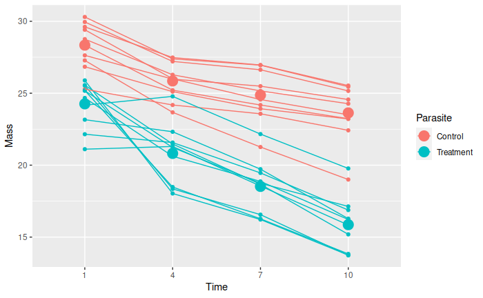

## Not really a multivariate question

- Only one response, mass
- But, we’ll use some clever tricks to find out what we want to know with MANOVA
- Doesn’t that look like an interaction plot?

## Possible outcomes

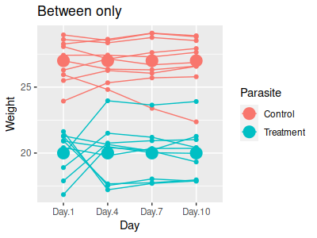

Only between-subjects

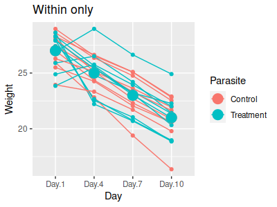

Only within-subjects

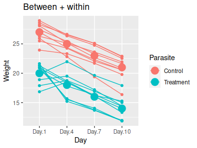

Both between + within, no interaction

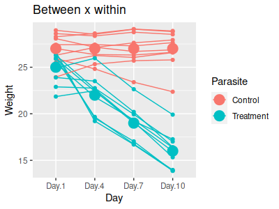

Between x within interaction

# Questions we can address:

- Is there a parasite treatment effect? (main effect of parasite)
- Is there a change over time?
- Does the pattern of change over time differ between the two groups?

## Arrange the data for analysis

- Multivariate organization
  - Each mouse a row
  - Each day of measurements a column
  - Column indicating parasite treatment
- Within-subjects = time
- Between-subjects = parasite

| Mouse | Parasite | Day.1 | Day.4 | Day.7 | Day.10 |
| --- | --- | --- | --- | --- | --- |
| 15 | Control | 30.30 | 27.39 | 26.95 | 25.45 |
| 8 | Control | 27.28 | 23.67 | 21.26 | 19.00 |
| 17 | Control | 29.95 | 27.21 | 26.63 | 25.16 |
| 13 | Control | 29.41 | 26.00 | 24.56 | 23.50 |
| 12 | Control | 27.63 | 25.98 | 25.49 | 24.56 |
| 11 | Control | 29.61 | 27.48 | 26.96 | 25.53 |
| 4 | Control | 26.84 | 25.11 | 23.92 | 23.21 |
| 19 | Control | 25.28 | 24.18 | 23.57 | 22.42 |
| 2 | Control | 28.34 | 25.21 | 24.18 | 23.23 |
| 6 | Control | 28.76 | 26.28 | 25.16 | 24.27 |
| 20 | Treatment | 24.17 | 24.78 | 22.16 | 19.77 |
| 18 | Treatment | 25.17 | 21.23 | 18.74 | 17.13 |
| 16 | Treatment | 25.56 | 21.47 | 18.67 | 15.19 |
| 14 | Treatment | 22.15 | 21.57 | 19.46 | 16.88 |
| 5 | Treatment | 25.53 | 18.35 | 16.56 | 13.73 |
| 3 | Treatment | 23.16 | 22.32 | 19.72 | 16.28 |
| 1 | Treatment | 24.67 | 20.62 | 18.87 | 16.22 |
| 10 | Treatment | 25.19 | 18.48 | 16.27 | 13.83 |
| 9 | Treatment | 21.11 | 21.30 | 18.55 | 15.84 |
| 7 | Treatment | 25.89 | 18.03 | 16.22 | 13.75 |

## Main effect of parasite

- Mean for each mouse
- Mean of the means for each parasite group
- Tested with one-way ANOVA

|  | Df | Sum.Sq | Mean.Sq | F | Pr(>F) |
| --- | --- | --- | --- | --- | --- |
| Parasite | 1 | 168.7 | 168.68 | 82.27 | <0.001 |
| Residuals | 18 | 36.9 | 2.05 |  |  |

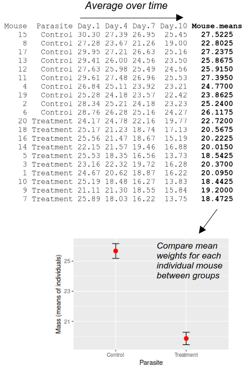

# Questions we can address:

- Is there a parasite treatment effect?
- Is there a change over time? (main effect of time)
- Does the pattern of change over time differ between the two groups?

## Flatness

- Main effect of time tested as flatness
  - Sequentially difference the data
  - Test if the sequential diffs are different from 0 with MANOVA
  - Like a paired MANOVA
- Similar to paired MANOVA, but uses within-groups SSCP

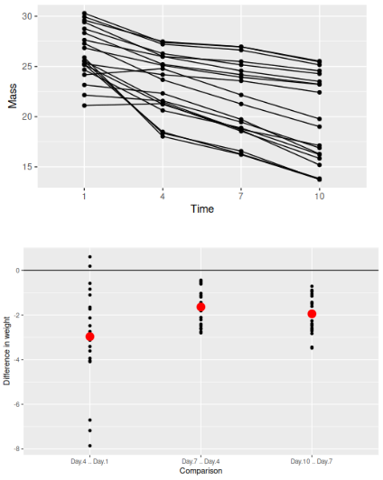

## Sequential differences

| Day.1 | Day.4 | Day.7 |
| --- | --- | --- |
| 30.30 | 27.39 | 26.95 |
| 27.28 | 23.67 | 21.26 |
| 29.95 | 27.21 | 26.63 |
| 29.41 | 26.00 | 24.56 |
| 27.63 | 25.98 | 25.49 |
| 29.61 | 27.48 | 26.96 |
| 26.84 | 25.11 | 23.92 |
| 25.28 | 24.18 | 23.57 |
| 28.34 | 25.21 | 24.18 |
| 28.76 | 26.28 | 25.16 |
| 24.17 | 24.78 | 22.16 |
| 25.17 | 21.23 | 18.74 |
| 25.56 | 21.47 | 18.67 |
| 22.15 | 21.57 | 19.46 |
| 25.53 | 18.35 | 16.56 |
| 23.16 | 22.32 | 19.72 |
| 24.67 | 20.62 | 18.87 |
| 25.19 | 18.48 | 16.27 |
| 21.11 | 21.30 | 18.55 |
| 25.89 | 18.03 | 16.22 |

-

| Day.4 | Day.7 | Day.10 |
| --- | --- | --- |
| 27.39 | 26.95 | 25.45 |
| 23.67 | 21.26 | 19.00 |
| 27.21 | 26.63 | 25.16 |
| 26.00 | 24.56 | 23.50 |
| 25.98 | 25.49 | 24.56 |
| 27.48 | 26.96 | 25.53 |
| 25.11 | 23.92 | 23.21 |
| 24.18 | 23.57 | 22.42 |
| 25.21 | 24.18 | 23.23 |
| 26.28 | 25.16 | 24.27 |
| 24.78 | 22.16 | 19.77 |
| 21.23 | 18.74 | 17.13 |
| 21.47 | 18.67 | 15.19 |
| 21.57 | 19.46 | 16.88 |
| 18.35 | 16.56 | 13.73 |
| 22.32 | 19.72 | 16.28 |
| 20.62 | 18.87 | 16.22 |
| 18.48 | 16.27 | 13.83 |
| 21.30 | 18.55 | 15.84 |
| 18.03 | 16.22 | 13.75 |

=

| Day.1 - Day.4 | Day.4 - Day.7 | Day.7 - Day.10 |
| --- | --- | --- |
| 2.91 | 0.44 | 1.50 |
| 3.61 | 2.41 | 2.26 |
| 2.74 | 0.58 | 1.47 |
| 3.41 | 1.44 | 1.06 |
| 1.65 | 0.49 | 0.93 |
| 2.13 | 0.52 | 1.43 |
| 1.73 | 1.19 | 0.71 |
| 1.10 | 0.61 | 1.15 |
| 3.13 | 1.03 | 0.95 |
| 2.48 | 1.12 | 0.89 |
| -0.61 | 2.62 | 2.39 |
| 3.94 | 2.49 | 1.61 |
| 4.09 | 2.80 | 3.48 |
| 0.58 | 2.11 | 2.58 |
| 7.18 | 1.79 | 2.83 |
| 0.84 | 2.60 | 3.44 |
| 4.05 | 1.75 | 2.65 |
| 6.71 | 2.21 | 2.44 |
| -0.19 | 2.75 | 2.71 |
| 7.86 | 1.81 | 2.47 |

## Within-group residuals

| D1-D4 | D4-D7 | D7-D10 |
| --- | --- | --- |
| 2.91 | 0.44 | 1.50 |
| 3.61 | 2.41 | 2.26 |
| 2.74 | 0.58 | 1.47 |
| 3.41 | 1.44 | 1.06 |
| 1.65 | 0.49 | 0.93 |
| 2.13 | 0.52 | 1.43 |
| 1.73 | 1.19 | 0.71 |
| 1.10 | 0.61 | 1.15 |
| 3.13 | 1.03 | 0.95 |
| 2.48 | 1.12 | 0.89 |
| -0.61 | 2.62 | 2.39 |
| 3.94 | 2.49 | 1.61 |
| 4.09 | 2.80 | 3.48 |
| 0.58 | 2.11 | 2.58 |
| 7.18 | 1.79 | 2.83 |
| 0.84 | 2.60 | 3.44 |
| 4.05 | 1.75 | 2.65 |
| 6.71 | 2.21 | 2.44 |
| -0.19 | 2.75 | 2.71 |
| 7.86 | 1.81 | 2.47 |

-

| Parasite | $\bar {D1-D4}$ | $\bar {D4-D7}$ | $\bar{D7-D10}$ |
| --- | --- | --- | --- |
| Control | 2.489 | 0.983 | 1.235 |
| Control | 2.489 | 0.983 | 1.235 |
| Control | 2.489 | 0.983 | 1.235 |
| Control | 2.489 | 0.983 | 1.235 |
| Control | 2.489 | 0.983 | 1.235 |
| Control | 2.489 | 0.983 | 1.235 |
| Control | 2.489 | 0.983 | 1.235 |
| Control | 2.489 | 0.983 | 1.235 |
| Control | 2.489 | 0.983 | 1.235 |
| Control | 2.489 | 0.983 | 1.235 |
| Treatment | 3.445 | 2.293 | 2.660 |
| Treatment | 3.445 | 2.293 | 2.660 |
| Treatment | 3.445 | 2.293 | 2.660 |
| Treatment | 3.445 | 2.293 | 2.660 |
| Treatment | 3.445 | 2.293 | 2.660 |
| Treatment | 3.445 | 2.293 | 2.660 |
| Treatment | 3.445 | 2.293 | 2.660 |
| Treatment | 3.445 | 2.293 | 2.660 |
| Treatment | 3.445 | 2.293 | 2.660 |
| Treatment | 3.445 | 2.293 | 2.660 |

=

| D1-D4<sub>r</sub> | D4-D7<sub>r</sub> | D7-D10<sub>r</sub> |
| --- | --- | --- |
| 0.421 | -0.543 | 0.265 |
| 1.121 | 1.427 | 1.025 |
| 0.251 | -0.403 | 0.235 |
| 0.921 | 0.457 | -0.175 |
| -0.839 | -0.493 | -0.305 |
| -0.359 | -0.463 | 0.195 |
| -0.759 | 0.207 | -0.525 |
| -1.389 | -0.373 | -0.085 |
| 0.641 | 0.047 | -0.285 |
| -0.009 | 0.137 | -0.345 |
| -4.055 | 0.327 | -0.270 |
| 0.495 | 0.197 | -1.050 |
| 0.645 | 0.507 | 0.820 |
| -2.865 | -0.183 | -0.080 |
| 3.735 | -0.503 | 0.170 |
| -2.605 | 0.307 | 0.780 |
| 0.605 | -0.543 | -0.010 |
| 3.265 | -0.083 | -0.220 |
| -3.635 | 0.457 | 0.050 |
| 4.415 | -0.483 | -0.190 |

## From there it’s just a T<sup>2</sup>

- Get the SSCP from the within-group residuals
- Calculate the T<sup>2</sup> statistic
- Calculate the approximate F, p-value
- For these data, p = 1.4 x 10<sup>-11</sup>
- The data are not flat, there is change over time

# Questions we can address:

- Is there a parasite treatment effect?
- Is there a change over time?
- Does the pattern of change over time differ between the two groups? (parasite x time interaction)

## Testing parallelism

- No interaction = change from one time to the next is same for both groups
- Compare sequential differences between groups with a MANOVA

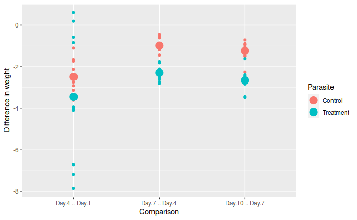

|  | Df | Pillai | approx.F | num.DF | den.DF | Pr(>F) |
| --- | --- | --- | --- | --- | --- | --- |
| Parasite | 1 | 0.766 | 17.51 | 3 | 16 | 2.62e-05 |
| Residuals | 18 |  |  |  |  |  |

The centroids are different, so the responses aren’t parallel

# Post-hocs

- Main effect of between-subjects factor - Tukey tests
- Main effect of within-subjects factor (time) - account for pairing
- Between x time - a few options…

## Between-subjects main effect post-hocs

- Just a one-way ANOVA of means for each subject
- Do Tukey post-hocs to compare the groups
- Not needed here, as there are only two groups

# Post-hocs

- Main effect of between-subjects factor - Tukey tests
- Main effect of within-subjects factor (time) - account for pairing
- Between x time - a few options…

## Within-subjects main effect post-hocs

- Only a main effect of Time, no Parasite x Time interaction:
  - Same difference between parasite groups at each time point, so just compare the time points
  - Account for the correlation between them
- What to compare?

## Test which time points are not flat

- Main effect of time = not flat
- Can test each set of differences against 0
- Essentially a paired t-test for each consecutive time point

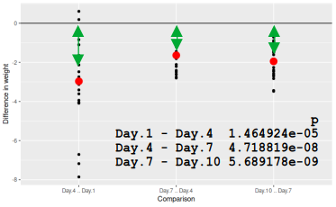

Sequential differences compared to 0

## Better: consecutive post-hocs

- The emmeans library can test for differences between sequential time points
- Accounts for the lack of independence
- Provides p-values adjusted for number of comparisons
- Uses model MSE for SE, better than separate t-tests
- Very nice!

```
 contrast       estimate    SE df t.ratio p.value
 Day.4 - Day.1     -2.97 0.516 18  -5.749 <0.0001
 Day.7 - Day.4     -1.64 0.117 18 -14.054 <0.0001
 Day.10 - Day.7    -1.95 0.111 18 -17.617 <0.0001
```

## Compare every time point to one another

- Mean of every time point compared
- With 4 time points there are 6 comparisons

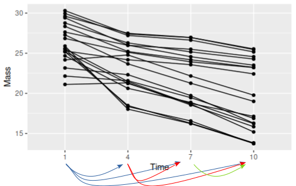

All possible pairs of time points

```
 contrast       estimate    SE df t.ratio p.value
 Day.1 - Day.4      2.97 0.516 18   5.749 <0.0001
 Day.1 - Day.7      4.61 0.503 18   9.150 <0.0001
 Day.1 - Day.10     6.55 0.523 18  12.538 <0.0001
 Day.4 - Day.7      1.64 0.117 18  14.054 <0.0001
 Day.4 - Day.10     3.59 0.185 18  19.415 <0.0001
 Day.7 - Day.10     1.95 0.111 18  17.617 <0.0001
```

## Compare all time points to initial

- Mean of first time point compared to three other
- Tests when masses change from initial conditions

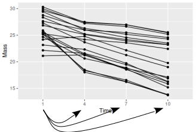

Change from initial

```
 contrast       estimate    SE df t.ratio p.value
 Day.4 - Day.1     -2.97 0.516 18  -5.749 <0.0001
 Day.7 - Day.1     -4.61 0.503 18  -9.150 <0.0001
 Day.10 - Day.1    -6.55 0.523 18 -12.538 <0.0001
```

# Post-hocs

- Main effect of between-subjects factor - Tukey tests
- Main effect of within-subjects factor (time) - account for pairing
- Between x time - a few options…

## Questions we can ask of a BxW interaction:

| Question | Procedure |
| --- | --- |
| At what time points are weights different between parasite groups? | Compare parasite groups conditional on time points |
| Within each parasite group, which sequential time points differ? | Compare time points conditional on parasite group |
| Which combinations of parasite and treatment are different? | Compare all possible combinations of parasite and time |

## Parasite groups at each time point

- At each time point, compare means of parasite groups

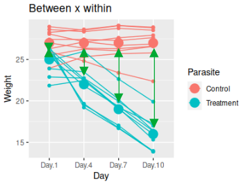

Differences at each time point

```
Time = Day.1:
 contrast            estimate    SE df t.ratio p.value
 Control - Treatment     4.08 0.715 18   5.706 <0.0001

Time = Day.4:
 contrast            estimate    SE df t.ratio p.value
 Control - Treatment     5.04 0.777 18   6.482 <0.0001

Time = Day.7:
 contrast            estimate    SE df t.ratio p.value
 Control - Treatment     6.35 0.806 18   7.877 <0.0001

Time = Day.10:
 contrast            estimate    SE df t.ratio p.value
 Control - Treatment     7.77 0.854 18   9.102 <0.0001
```

## Time points given parasite group

- For each parasite group, compare time points
- For simplicity, just consecutive shown here

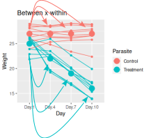

Differences between time points, by parasite group

```
 contrast       Parasite  estimate    SE df t.ratio p.value
 Day.4 - Day.1  Control     -2.489 0.730 18  -3.410  0.0177
 Day.7 - Day.4  Control     -0.983 0.165 18  -5.964 <0.0001
 Day.10 - Day.7 Control     -1.235 0.156 18  -7.900 <0.0001
 Day.4 - Day.1  Treatment   -3.445 0.730 18  -4.720  0.0010
 Day.7 - Day.4  Treatment   -2.293 0.165 18 -13.912 <0.0001
 Day.10 - Day.7 Treatment   -2.660 0.156 18 -17.014 <0.0001

P value adjustment: mvt method for 6 tests
```

## Every combination of time and parasite

- Most information rich, in that all comparisons are made
- Lowest power because of the number that need to be corrected for
- Many comparisons not very interesting
- Probably the least sensible

```
 contrast                           estimate    SE df t.ratio p.value
 Day.1 Control - Day.4 Control         2.489 0.730 18   3.410  0.0142
 Day.1 Control - Day.7 Control         3.472 0.712 18   4.878  0.0008
 Day.1 Control - Day.10 Control        4.707 0.739 18   6.369 <0.0001
 Day.1 Control - Day.1 Treatment       4.080 0.715 18   5.706  0.0002
 Day.1 Control - Day.4 Treatment       7.525 0.747 18  10.079 <0.0001
 Day.1 Control - Day.7 Treatment       9.818 0.762 18  12.889 <0.0001
 Day.1 Control - Day.10 Treatment     12.478 0.787 18  15.846 <0.0001
 Day.4 Control - Day.7 Control         0.983 0.165 18   5.964  0.0001
 Day.4 Control - Day.10 Control        2.218 0.261 18   8.493 <0.0001
 Day.4 Control - Day.1 Treatment       1.591 0.747 18   2.131  0.1414
 Day.4 Control - Day.4 Treatment       5.036 0.777 18   6.482 <0.0001
 Day.4 Control - Day.7 Treatment       7.329 0.791 18   9.261 <0.0001
 Day.4 Control - Day.10 Treatment      9.989 0.816 18  12.238 <0.0001
 Day.7 Control - Day.10 Control        1.235 0.156 18   7.900 <0.0001
 Day.7 Control - Day.1 Treatment       0.608 0.762 18   0.798  0.8703
 Day.7 Control - Day.4 Treatment       4.053 0.791 18   5.121  0.0006
 Day.7 Control - Day.7 Treatment       6.346 0.806 18   7.877 <0.0001
 Day.7 Control - Day.10 Treatment      9.006 0.830 18  10.850 <0.0001
 Day.10 Control - Day.1 Treatment     -0.627 0.787 18  -0.796  0.8703
 Day.10 Control - Day.4 Treatment      2.818 0.816 18   3.453  0.0142
 Day.10 Control - Day.7 Treatment      5.111 0.830 18   6.157 <0.0001
 Day.10 Control - Day.10 Treatment     7.771 0.854 18   9.102 <0.0001
 Day.1 Treatment - Day.4 Treatment     3.445 0.730 18   4.720  0.0010
 Day.1 Treatment - Day.7 Treatment     5.738 0.712 18   8.062 <0.0001
 Day.1 Treatment - Day.10 Treatment    8.398 0.739 18  11.363 <0.0001
 Day.4 Treatment - Day.7 Treatment     2.293 0.165 18  13.912 <0.0001
 Day.4 Treatment - Day.10 Treatment    4.953 0.261 18  18.965 <0.0001
 Day.7 Treatment - Day.10 Treatment    2.660 0.156 18  17.014 <0.0001
```

## Consider a compact letter display

Useful when there are many means to compare

[output not shown]

Shared letter = not different

# Wrap-up

- Repeated measures data requires specialized analysis approaches
- Profile analysis uses MANOVA to analyze RM data
- Post-hocs should be used that:
  - Account for lack of independence between measurements
  - Only test differences that are of interest
  - It is rarely a good idea to compare all possible groups at all possible time points